# Risk Factor Analysis

## Outcome Variable

**Outcome Variable:** wast_rec90d

## Predictor Variables

**Intervention Variable:** parity

**Adjustment Set:**

- arm
- W_mage
- meducyrs
- feducyrs
- hhwealth_quart
- W_mhtcm
- vagbrth
- W_nrooms
- impsan
- delta_W_mage
- delta_meducyrs
- delta_feducyrs
- delta_hhwealth_quart
- delta_W_mhtcm
- delta_vagbrth
- delta_W_nrooms
- delta_impsan

## Stratifying Variables

The analysis was stratified on these variable(s):

- agecat
- studyid
- country

## Data Summary

| agecat | studyid | country | parity | wast_rec90d | n_cell | n |
| --- | --- | --- | --- | --- | --- | --- |
| 0-24 months | ki1000304b-SAS-CompFeed | INDIA | 1 | 0 | 136 | 814 |
| 0-24 months | ki1000304b-SAS-CompFeed | INDIA | 1 | 1 | 91 | 814 |
| 0-24 months | ki1000304b-SAS-CompFeed | INDIA | 2 | 0 | 110 | 814 |
| 0-24 months | ki1000304b-SAS-CompFeed | INDIA | 2 | 1 | 62 | 814 |
| 0-24 months | ki1000304b-SAS-CompFeed | INDIA | 3+ | 0 | 258 | 814 |
| 0-24 months | ki1000304b-SAS-CompFeed | INDIA | 3+ | 1 | 157 | 814 |
| 0-24 months | ki1000304b-SAS-FoodSuppl | INDIA | 1 | 0 | 30 | 223 |
| 0-24 months | ki1000304b-SAS-FoodSuppl | INDIA | 1 | 1 | 2 | 223 |
| 0-24 months | ki1000304b-SAS-FoodSuppl | INDIA | 2 | 0 | 47 | 223 |
| 0-24 months | ki1000304b-SAS-FoodSuppl | INDIA | 2 | 1 | 3 | 223 |
| 0-24 months | ki1000304b-SAS-FoodSuppl | INDIA | 3+ | 0 | 133 | 223 |
| 0-24 months | ki1000304b-SAS-FoodSuppl | INDIA | 3+ | 1 | 8 | 223 |
| 0-24 months | ki1017093b-PROVIDE | BANGLADESH | 1 | 0 | 52 | 307 |
| 0-24 months | ki1017093b-PROVIDE | BANGLADESH | 1 | 1 | 76 | 307 |
| 0-24 months | ki1017093b-PROVIDE | BANGLADESH | 2 | 0 | 40 | 307 |
| 0-24 months | ki1017093b-PROVIDE | BANGLADESH | 2 | 1 | 63 | 307 |
| 0-24 months | ki1017093b-PROVIDE | BANGLADESH | 3+ | 0 | 36 | 307 |
| 0-24 months | ki1017093b-PROVIDE | BANGLADESH | 3+ | 1 | 40 | 307 |
| 0-24 months | ki1066203-TanzaniaChild2 | TANZANIA, UNITED REPUBLIC OF | 1 | 0 | 90 | 702 |
| 0-24 months | ki1066203-TanzaniaChild2 | TANZANIA, UNITED REPUBLIC OF | 1 | 1 | 158 | 702 |
| 0-24 months | ki1066203-TanzaniaChild2 | TANZANIA, UNITED REPUBLIC OF | 2 | 0 | 83 | 702 |
| 0-24 months | ki1066203-TanzaniaChild2 | TANZANIA, UNITED REPUBLIC OF | 2 | 1 | 155 | 702 |
| 0-24 months | ki1066203-TanzaniaChild2 | TANZANIA, UNITED REPUBLIC OF | 3+ | 0 | 90 | 702 |
| 0-24 months | ki1066203-TanzaniaChild2 | TANZANIA, UNITED REPUBLIC OF | 3+ | 1 | 126 | 702 |
| 0-24 months | ki1101329-Keneba | GAMBIA | 1 | 0 | 44 | 1164 |
| 0-24 months | ki1101329-Keneba | GAMBIA | 1 | 1 | 79 | 1164 |
| 0-24 months | ki1101329-Keneba | GAMBIA | 2 | 0 | 43 | 1164 |
| 0-24 months | ki1101329-Keneba | GAMBIA | 2 | 1 | 66 | 1164 |
| 0-24 months | ki1101329-Keneba | GAMBIA | 3+ | 0 | 429 | 1164 |
| 0-24 months | ki1101329-Keneba | GAMBIA | 3+ | 1 | 503 | 1164 |

[output cut: 168 more lines]

The following strata were considered:

- agecat: 0-24 months, studyid: ki1000304b-SAS-CompFeed, country: INDIA
- agecat: 0-24 months, studyid: ki1000304b-SAS-FoodSuppl, country: INDIA
- agecat: 0-24 months, studyid: ki1017093b-PROVIDE, country: BANGLADESH
- agecat: 0-24 months, studyid: ki1066203-TanzaniaChild2, country: TANZANIA, UNITED REPUBLIC OF
- agecat: 0-24 months, studyid: ki1101329-Keneba, country: GAMBIA
- agecat: 0-24 months, studyid: ki1113344-GMS-Nepal, country: NEPAL
- agecat: 0-24 months, studyid: ki1126311-ZVITAMBO, country: ZIMBABWE
- agecat: 0-24 months, studyid: ki1135781-COHORTS, country: GUATEMALA
- agecat: 0-24 months, studyid: ki1135781-COHORTS, country: INDIA
- agecat: 0-24 months, studyid: ki1135781-COHORTS, country: PHILIPPINES
- agecat: 0-24 months, studyid: kiGH5241-JiVitA-3, country: BANGLADESH
- agecat: 0-6 months, studyid: ki1000304b-SAS-CompFeed, country: INDIA
- agecat: 0-6 months, studyid: ki1000304b-SAS-FoodSuppl, country: INDIA
- agecat: 0-6 months, studyid: ki1017093b-PROVIDE, country: BANGLADESH
- agecat: 0-6 months, studyid: ki1066203-TanzaniaChild2, country: TANZANIA, UNITED REPUBLIC OF
- agecat: 0-6 months, studyid: ki1101329-Keneba, country: GAMBIA
- agecat: 0-6 months, studyid: ki1113344-GMS-Nepal, country: NEPAL
- agecat: 0-6 months, studyid: ki1126311-ZVITAMBO, country: ZIMBABWE
- agecat: 0-6 months, studyid: ki1135781-COHORTS, country: GUATEMALA
- agecat: 0-6 months, studyid: ki1135781-COHORTS, country: INDIA
- agecat: 0-6 months, studyid: ki1135781-COHORTS, country: PHILIPPINES
- agecat: 0-6 months, studyid: kiGH5241-JiVitA-3, country: BANGLADESH
- agecat: 6-24 months, studyid: ki1000304b-SAS-CompFeed, country: INDIA
- agecat: 6-24 months, studyid: ki1000304b-SAS-FoodSuppl, country: INDIA
- agecat: 6-24 months, studyid: ki1017093b-PROVIDE, country: BANGLADESH
- agecat: 6-24 months, studyid: ki1066203-TanzaniaChild2, country: TANZANIA, UNITED REPUBLIC OF
- agecat: 6-24 months, studyid: ki1101329-Keneba, country: GAMBIA
- agecat: 6-24 months, studyid: ki1113344-GMS-Nepal, country: NEPAL
- agecat: 6-24 months, studyid: ki1126311-ZVITAMBO, country: ZIMBABWE
- agecat: 6-24 months, studyid: ki1135781-COHORTS, country: GUATEMALA
- agecat: 6-24 months, studyid: ki1135781-COHORTS, country: INDIA
- agecat: 6-24 months, studyid: ki1135781-COHORTS, country: PHILIPPINES
- agecat: 6-24 months, studyid: kiGH5241-JiVitA-3, country: BANGLADESH

### Dropped Strata

Some strata were dropped due to rare outcomes:

- agecat: 0-24 months, studyid: ki1000304b-SAS-FoodSuppl, country: INDIA
- agecat: 0-6 months, studyid: ki1000304b-SAS-FoodSuppl, country: INDIA
- agecat: 6-24 months, studyid: ki1000304b-SAS-FoodSuppl, country: INDIA
- agecat: 6-24 months, studyid: ki1135781-COHORTS, country: GUATEMALA
- agecat: 6-24 months, studyid: ki1135781-COHORTS, country: INDIA
- agecat: 6-24 months, studyid: kiGH5241-JiVitA-3, country: BANGLADESH

## Methods Detail

We’re interested in the causal parameters $E[Y_a]$ for all values of $a \in \mathcal{A}$. These parameters represent the mean outcome if, possibly contrary to fact, we intervened to set all units to have $A=a$. Under the randomization and positivity assumptions, these are identified by the statistical parameters $\psi_a=E_W[E_{Y|A,W}(Y|A=a,W)]$. In addition, we’re interested in the mean of $Y$, $E[Y]$ under no intervention (the observed mean). We will estimate these parameters by using SuperLearner to fit the relevant likelihood factors – $E_{Y|A,W}(Y|A=a,W)$ and $p(A=a|W)$, and then updating our likelihood fit using a joint TMLE.

For unadjusted analyses ($W=\{\}$), initial likelihoods were estimated using Lrnr_glm to estimate the simple $E(Y|A)$ and Lrnr_mean to estimate $p(A)$. For adjusted analyses, a small library containing Lrnr_glmnet, Lrnr_xgboost, and Lrnr_mean was used.

Having estimated these parameters, we will then use the delta method to estimate relative risks and attributable risks relative to a prespecified baseline level of $A$.

# Results Detail

## Results Plots

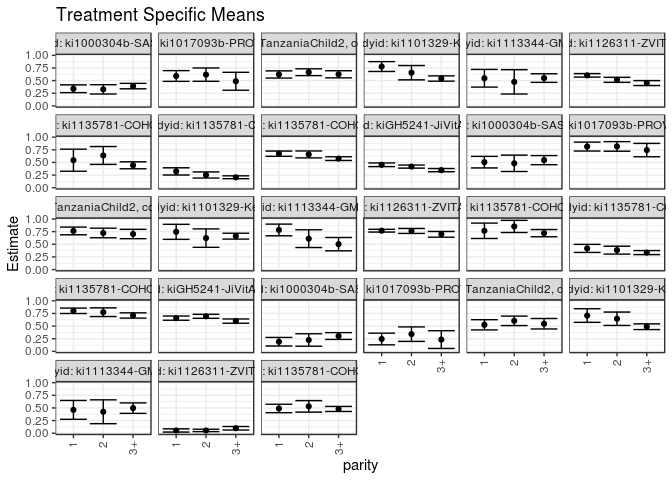

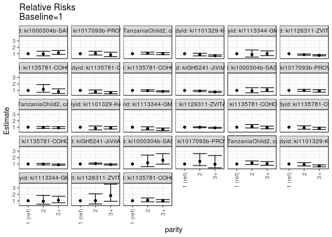

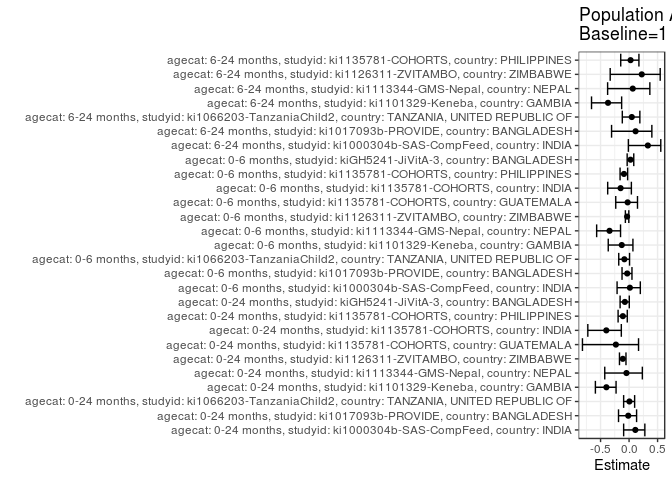

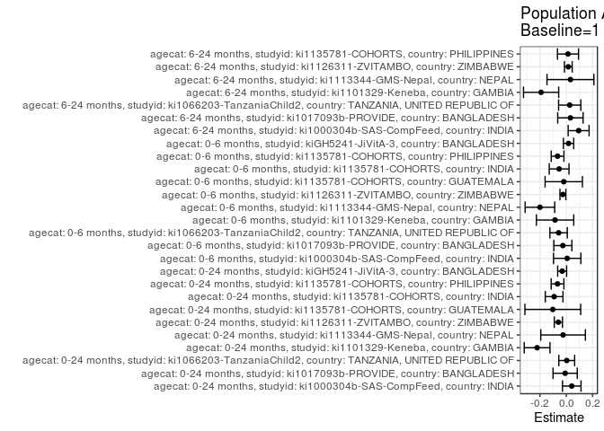

## Results Table

### Parameter: TSM

| agecat | studyid | country | intervention_level | baseline_level | estimate | ci_lower | ci_upper |
| --- | --- | --- | --- | --- | --- | --- | --- |
| 0-24 months | ki1000304b-SAS-CompFeed | INDIA | 1 | NA | 0.3389645 | 0.2623743 | 0.4155547 |
| 0-24 months | ki1000304b-SAS-CompFeed | INDIA | 2 | NA | 0.3267343 | 0.2341105 | 0.4193580 |
| 0-24 months | ki1000304b-SAS-CompFeed | INDIA | 3+ | NA | 0.3917084 | 0.3381019 | 0.4453150 |
| 0-24 months | ki1017093b-PROVIDE | BANGLADESH | 1 | NA | 0.5914283 | 0.4852115 | 0.6976451 |
| 0-24 months | ki1017093b-PROVIDE | BANGLADESH | 2 | NA | 0.6182930 | 0.4863670 | 0.7502189 |
| 0-24 months | ki1017093b-PROVIDE | BANGLADESH | 3+ | NA | 0.4871049 | 0.3096542 | 0.6645556 |
| 0-24 months | ki1066203-TanzaniaChild2 | TANZANIA, UNITED REPUBLIC OF | 1 | NA | 0.6217803 | 0.5507988 | 0.6927618 |
| 0-24 months | ki1066203-TanzaniaChild2 | TANZANIA, UNITED REPUBLIC OF | 2 | NA | 0.6656629 | 0.5981940 | 0.7331319 |
| 0-24 months | ki1066203-TanzaniaChild2 | TANZANIA, UNITED REPUBLIC OF | 3+ | NA | 0.6252437 | 0.5552096 | 0.6952777 |
| 0-24 months | ki1101329-Keneba | GAMBIA | 1 | NA | 0.7780925 | 0.6809941 | 0.8751909 |
| 0-24 months | ki1101329-Keneba | GAMBIA | 2 | NA | 0.6562782 | 0.5145605 | 0.7979960 |
| 0-24 months | ki1101329-Keneba | GAMBIA | 3+ | NA | 0.5407155 | 0.4887143 | 0.5927167 |
| 0-24 months | ki1113344-GMS-Nepal | NEPAL | 1 | NA | 0.5463405 | 0.3714739 | 0.7212071 |
| 0-24 months | ki1113344-GMS-Nepal | NEPAL | 2 | NA | 0.4753127 | 0.2342269 | 0.7163985 |
| 0-24 months | ki1113344-GMS-Nepal | NEPAL | 3+ | NA | 0.5502552 | 0.4653299 | 0.6351805 |
| 0-24 months | ki1126311-ZVITAMBO | ZIMBABWE | 1 | NA | 0.6038550 | 0.5691927 | 0.6385173 |
| 0-24 months | ki1126311-ZVITAMBO | ZIMBABWE | 2 | NA | 0.5153324 | 0.4658677 | 0.5647971 |
| 0-24 months | ki1126311-ZVITAMBO | ZIMBABWE | 3+ | NA | 0.4511995 | 0.4024006 | 0.4999985 |
| 0-24 months | ki1135781-COHORTS | GUATEMALA | 1 | NA | 0.5442946 | 0.3258192 | 0.7627700 |
| 0-24 months | ki1135781-COHORTS | GUATEMALA | 2 | NA | 0.6379494 | 0.4612015 | 0.8146972 |
| 0-24 months | ki1135781-COHORTS | GUATEMALA | 3+ | NA | 0.4436918 | 0.3746645 | 0.5127191 |
| 0-24 months | ki1135781-COHORTS | INDIA | 1 | NA | 0.3227781 | 0.2514636 | 0.3940926 |
| 0-24 months | ki1135781-COHORTS | INDIA | 2 | NA | 0.2519557 | 0.1916183 | 0.3122931 |
| 0-24 months | ki1135781-COHORTS | INDIA | 3+ | NA | 0.2064589 | 0.1780452 | 0.2348725 |
| 0-24 months | ki1135781-COHORTS | PHILIPPINES | 1 | NA | 0.6730869 | 0.6213994 | 0.7247745 |
| 0-24 months | ki1135781-COHORTS | PHILIPPINES | 2 | NA | 0.6581379 | 0.5897001 | 0.7265757 |
| 0-24 months | ki1135781-COHORTS | PHILIPPINES | 3+ | NA | 0.5754738 | 0.5388683 | 0.6120794 |
| 0-24 months | kiGH5241-JiVitA-3 | BANGLADESH | 1 | NA | 0.4536125 | 0.4178267 | 0.4893984 |
| 0-24 months | kiGH5241-JiVitA-3 | BANGLADESH | 2 | NA | 0.4183127 | 0.3874835 | 0.4491420 |
| 0-24 months | kiGH5241-JiVitA-3 | BANGLADESH | 3+ | NA | 0.3478554 | 0.3162063 | 0.3795045 |

[output cut: 51 more lines]

### Parameter: E(Y)

| agecat | studyid | country | intervention_level | baseline_level | estimate | ci_lower | ci_upper |
| --- | --- | --- | --- | --- | --- | --- | --- |
| 0-24 months | ki1000304b-SAS-CompFeed | INDIA | NA | NA | 0.3808354 | 0.3457640 | 0.4159068 |
| 0-24 months | ki1017093b-PROVIDE | BANGLADESH | NA | NA | 0.5830619 | 0.5262762 | 0.6398476 |
| 0-24 months | ki1066203-TanzaniaChild2 | TANZANIA, UNITED REPUBLIC OF | NA | NA | 0.6253561 | 0.5873792 | 0.6633330 |
| 0-24 months | ki1101329-Keneba | GAMBIA | NA | NA | 0.5567010 | 0.5253304 | 0.5880717 |
| 0-24 months | ki1113344-GMS-Nepal | NEPAL | NA | NA | 0.5222816 | 0.4773852 | 0.5671781 |
| 0-24 months | ki1126311-ZVITAMBO | ZIMBABWE | NA | NA | 0.5440559 | 0.5275873 | 0.5605246 |
| 0-24 months | ki1135781-COHORTS | GUATEMALA | NA | NA | 0.4421053 | 0.3904403 | 0.4937702 |
| 0-24 months | ki1135781-COHORTS | INDIA | NA | NA | 0.2306792 | 0.2105836 | 0.2507747 |
| 0-24 months | ki1135781-COHORTS | PHILIPPINES | NA | NA | 0.6068680 | 0.5823645 | 0.6313715 |
| 0-24 months | kiGH5241-JiVitA-3 | BANGLADESH | NA | NA | 0.4224719 | 0.4113451 | 0.4335987 |
| 0-6 months | ki1000304b-SAS-CompFeed | INDIA | NA | NA | 0.5131965 | 0.4596632 | 0.5667297 |
| 0-6 months | ki1017093b-PROVIDE | BANGLADESH | NA | NA | 0.7880435 | 0.7295878 | 0.8464992 |
| 0-6 months | ki1066203-TanzaniaChild2 | TANZANIA, UNITED REPUBLIC OF | NA | NA | 0.7053571 | 0.6558827 | 0.7548316 |
| 0-6 months | ki1101329-Keneba | GAMBIA | NA | NA | 0.6613924 | 0.6093076 | 0.7134773 |
| 0-6 months | ki1113344-GMS-Nepal | NEPAL | NA | NA | 0.5833333 | 0.5108676 | 0.6557991 |
| 0-6 months | ki1126311-ZVITAMBO | ZIMBABWE | NA | NA | 0.7433453 | 0.7262923 | 0.7603982 |
| 0-6 months | ki1135781-COHORTS | GUATEMALA | NA | NA | 0.7476636 | 0.6894668 | 0.8058603 |
| 0-6 months | ki1135781-COHORTS | INDIA | NA | NA | 0.3641405 | 0.3354558 | 0.3928252 |
| 0-6 months | ki1135781-COHORTS | PHILIPPINES | NA | NA | 0.7367021 | 0.7051294 | 0.7682749 |
| 0-6 months | kiGH5241-JiVitA-3 | BANGLADESH | NA | NA | 0.6752588 | 0.6619177 | 0.6885999 |
| 6-24 months | ki1000304b-SAS-CompFeed | INDIA | NA | NA | 0.2854123 | 0.2436284 | 0.3271961 |
| 6-24 months | ki1017093b-PROVIDE | BANGLADESH | NA | NA | 0.2764228 | 0.1950773 | 0.3577682 |
| 6-24 months | ki1066203-TanzaniaChild2 | TANZANIA, UNITED REPUBLIC OF | NA | NA | 0.5519126 | 0.4992021 | 0.6046230 |
| 6-24 months | ki1101329-Keneba | GAMBIA | NA | NA | 0.5176887 | 0.4814695 | 0.5539079 |
| 6-24 months | ki1113344-GMS-Nepal | NEPAL | NA | NA | 0.4934383 | 0.4388573 | 0.5480193 |
| 6-24 months | ki1126311-ZVITAMBO | ZIMBABWE | NA | NA | 0.0699433 | 0.0547084 | 0.0851781 |
| 6-24 months | ki1135781-COHORTS | PHILIPPINES | NA | NA | 0.5026681 | 0.4688378 | 0.5364984 |

### Parameter: RR

| agecat | studyid | country | intervention_level | baseline_level | estimate | ci_lower | ci_upper |
| --- | --- | --- | --- | --- | --- | --- | --- |
| 0-24 months | ki1000304b-SAS-CompFeed | INDIA | 1 | 1 | 1.0000000 | 1.0000000 | 1.0000000 |
| 0-24 months | ki1000304b-SAS-CompFeed | INDIA | 2 | 1 | 0.9639188 | 0.6709015 | 1.3849119 |
| 0-24 months | ki1000304b-SAS-CompFeed | INDIA | 3+ | 1 | 1.1556031 | 0.8875217 | 1.5046602 |
| 0-24 months | ki1017093b-PROVIDE | BANGLADESH | 1 | 1 | 1.0000000 | 1.0000000 | 1.0000000 |
| 0-24 months | ki1017093b-PROVIDE | BANGLADESH | 2 | 1 | 1.0454233 | 0.7902357 | 1.3830177 |
| 0-24 months | ki1017093b-PROVIDE | BANGLADESH | 3+ | 1 | 0.8236077 | 0.5480913 | 1.2376216 |
| 0-24 months | ki1066203-TanzaniaChild2 | TANZANIA, UNITED REPUBLIC OF | 1 | 1 | 1.0000000 | 1.0000000 | 1.0000000 |
| 0-24 months | ki1066203-TanzaniaChild2 | TANZANIA, UNITED REPUBLIC OF | 2 | 1 | 1.0705758 | 0.9191179 | 1.2469919 |
| 0-24 months | ki1066203-TanzaniaChild2 | TANZANIA, UNITED REPUBLIC OF | 3+ | 1 | 1.0055701 | 0.8566320 | 1.1804034 |
| 0-24 months | ki1101329-Keneba | GAMBIA | 1 | 1 | 1.0000000 | 1.0000000 | 1.0000000 |
| 0-24 months | ki1101329-Keneba | GAMBIA | 2 | 1 | 0.8434450 | 0.6573738 | 1.0821842 |
| 0-24 months | ki1101329-Keneba | GAMBIA | 3+ | 1 | 0.6949245 | 0.5936093 | 0.8135318 |
| 0-24 months | ki1113344-GMS-Nepal | NEPAL | 1 | 1 | 1.0000000 | 1.0000000 | 1.0000000 |
| 0-24 months | ki1113344-GMS-Nepal | NEPAL | 2 | 1 | 0.8699936 | 0.4777139 | 1.5843976 |
| 0-24 months | ki1113344-GMS-Nepal | NEPAL | 3+ | 1 | 1.0071653 | 0.7059156 | 1.4369735 |
| 0-24 months | ki1126311-ZVITAMBO | ZIMBABWE | 1 | 1 | 1.0000000 | 1.0000000 | 1.0000000 |
| 0-24 months | ki1126311-ZVITAMBO | ZIMBABWE | 2 | 1 | 0.8534041 | 0.7633122 | 0.9541293 |
| 0-24 months | ki1126311-ZVITAMBO | ZIMBABWE | 3+ | 1 | 0.7471984 | 0.6613891 | 0.8441408 |
| 0-24 months | ki1135781-COHORTS | GUATEMALA | 1 | 1 | 1.0000000 | 1.0000000 | 1.0000000 |
| 0-24 months | ki1135781-COHORTS | GUATEMALA | 2 | 1 | 1.1720664 | 0.7196185 | 1.9089830 |
| 0-24 months | ki1135781-COHORTS | GUATEMALA | 3+ | 1 | 0.8151685 | 0.5293251 | 1.2553714 |
| 0-24 months | ki1135781-COHORTS | INDIA | 1 | 1 | 1.0000000 | 1.0000000 | 1.0000000 |
| 0-24 months | ki1135781-COHORTS | INDIA | 2 | 1 | 0.7805850 | 0.5634544 | 1.0813881 |
| 0-24 months | ki1135781-COHORTS | INDIA | 3+ | 1 | 0.6396310 | 0.4930555 | 0.8297804 |
| 0-24 months | ki1135781-COHORTS | PHILIPPINES | 1 | 1 | 1.0000000 | 1.0000000 | 1.0000000 |
| 0-24 months | ki1135781-COHORTS | PHILIPPINES | 2 | 1 | 0.9777903 | 0.8593812 | 1.1125144 |
| 0-24 months | ki1135781-COHORTS | PHILIPPINES | 3+ | 1 | 0.8549770 | 0.7739134 | 0.9445316 |
| 0-24 months | kiGH5241-JiVitA-3 | BANGLADESH | 1 | 1 | 1.0000000 | 1.0000000 | 1.0000000 |
| 0-24 months | kiGH5241-JiVitA-3 | BANGLADESH | 2 | 1 | 0.9221807 | 0.8278201 | 1.0272972 |
| 0-24 months | kiGH5241-JiVitA-3 | BANGLADESH | 3+ | 1 | 0.7668558 | 0.6798743 | 0.8649656 |

[output cut: 51 more lines]

### Parameter: PAR

| agecat | studyid | country | intervention_level | baseline_level | estimate | ci_lower | ci_upper |
| --- | --- | --- | --- | --- | --- | --- | --- |
| 0-24 months | ki1000304b-SAS-CompFeed | INDIA | 1 | NA | 0.0418709 | -0.0285728 | 0.1123145 |
| 0-24 months | ki1017093b-PROVIDE | BANGLADESH | 1 | NA | -0.0083664 | -0.1003168 | 0.0835839 |
| 0-24 months | ki1066203-TanzaniaChild2 | TANZANIA, UNITED REPUBLIC OF | 1 | NA | 0.0035758 | -0.0565974 | 0.0637491 |
| 0-24 months | ki1101329-Keneba | GAMBIA | 1 | NA | -0.2213914 | -0.3190702 | -0.1237127 |
| 0-24 months | ki1113344-GMS-Nepal | NEPAL | 1 | NA | -0.0240589 | -0.1935471 | 0.1454293 |
| 0-24 months | ki1126311-ZVITAMBO | ZIMBABWE | 1 | NA | -0.0597991 | -0.0907232 | -0.0288749 |
| 0-24 months | ki1135781-COHORTS | GUATEMALA | 1 | NA | -0.1021893 | -0.3140082 | 0.1096295 |
| 0-24 months | ki1135781-COHORTS | INDIA | 1 | NA | -0.0920989 | -0.1593581 | -0.0248398 |
| 0-24 months | ki1135781-COHORTS | PHILIPPINES | 1 | NA | -0.0662190 | -0.1146336 | -0.0178043 |
| 0-24 months | kiGH5241-JiVitA-3 | BANGLADESH | 1 | NA | -0.0311406 | -0.0651383 | 0.0028571 |
| 0-6 months | ki1000304b-SAS-CompFeed | INDIA | 1 | NA | 0.0073513 | -0.0965061 | 0.1112088 |
| 0-6 months | ki1017093b-PROVIDE | BANGLADESH | 1 | NA | -0.0258037 | -0.0943223 | 0.0427148 |
| 0-6 months | ki1066203-TanzaniaChild2 | TANZANIA, UNITED REPUBLIC OF | 1 | NA | -0.0580103 | -0.1240642 | 0.0080435 |
| 0-6 months | ki1101329-Keneba | GAMBIA | 1 | NA | -0.0848528 | -0.2266953 | 0.0569896 |
| 0-6 months | ki1113344-GMS-Nepal | NEPAL | 1 | NA | -0.2000160 | -0.3124957 | -0.0875363 |
| 0-6 months | ki1126311-ZVITAMBO | ZIMBABWE | 1 | NA | -0.0254845 | -0.0478185 | -0.0031505 |
| 0-6 months | ki1135781-COHORTS | GUATEMALA | 1 | NA | -0.0190031 | -0.1607938 | 0.1227875 |
| 0-6 months | ki1135781-COHORTS | INDIA | 1 | NA | -0.0541762 | -0.1292081 | 0.0208558 |
| 0-6 months | ki1135781-COHORTS | PHILIPPINES | 1 | NA | -0.0659120 | -0.1141721 | -0.0176518 |
| 0-6 months | kiGH5241-JiVitA-3 | BANGLADESH | 1 | NA | 0.0176018 | -0.0214446 | 0.0566482 |
| 6-24 months | ki1000304b-SAS-CompFeed | INDIA | 1 | NA | 0.0940609 | 0.0145286 | 0.1735931 |
| 6-24 months | ki1017093b-PROVIDE | BANGLADESH | 1 | NA | 0.0315248 | -0.0648316 | 0.1278812 |
| 6-24 months | ki1066203-TanzaniaChild2 | TANZANIA, UNITED REPUBLIC OF | 1 | NA | 0.0262518 | -0.0582301 | 0.1107336 |
| 6-24 months | ki1101329-Keneba | GAMBIA | 1 | NA | -0.1911060 | -0.3246747 | -0.0575373 |
| 6-24 months | ki1113344-GMS-Nepal | NEPAL | 1 | NA | 0.0319344 | -0.1462739 | 0.2101426 |
| 6-24 months | ki1126311-ZVITAMBO | ZIMBABWE | 1 | NA | 0.0155620 | -0.0138468 | 0.0449708 |
| 6-24 months | ki1135781-COHORTS | PHILIPPINES | 1 | NA | 0.0131711 | -0.0667617 | 0.0931039 |

### Parameter: PAF

| agecat | studyid | country | intervention_level | baseline_level | estimate | ci_lower | ci_upper |
| --- | --- | --- | --- | --- | --- | --- | --- |
| 0-24 months | ki1000304b-SAS-CompFeed | INDIA | 1 | NA | 0.1099448 | -0.0951684 | 0.2766425 |
| 0-24 months | ki1017093b-PROVIDE | BANGLADESH | 1 | NA | -0.0143491 | -0.1850409 | 0.1317565 |
| 0-24 months | ki1066203-TanzaniaChild2 | TANZANIA, UNITED REPUBLIC OF | 1 | NA | 0.0057181 | -0.0953128 | 0.0974300 |
| 0-24 months | ki1101329-Keneba | GAMBIA | 1 | NA | -0.3976846 | -0.5907235 | -0.2280716 |
| 0-24 months | ki1113344-GMS-Nepal | NEPAL | 1 | NA | -0.0460649 | -0.4266424 | 0.2329880 |
| 0-24 months | ki1126311-ZVITAMBO | ZIMBABWE | 1 | NA | -0.1099135 | -0.1684259 | -0.0543313 |
| 0-24 months | ki1135781-COHORTS | GUATEMALA | 1 | NA | -0.2311425 | -0.8176192 | 0.1661005 |
| 0-24 months | ki1135781-COHORTS | INDIA | 1 | NA | -0.3992512 | -0.7234730 | -0.1360224 |
| 0-24 months | ki1135781-COHORTS | PHILIPPINES | 1 | NA | -0.1091159 | -0.1925057 | -0.0315574 |
| 0-24 months | kiGH5241-JiVitA-3 | BANGLADESH | 1 | NA | -0.0737105 | -0.1572987 | 0.0038404 |
| 0-6 months | ki1000304b-SAS-CompFeed | INDIA | 1 | NA | 0.0143245 | -0.2102408 | 0.1972208 |
| 0-6 months | ki1017093b-PROVIDE | BANGLADESH | 1 | NA | -0.0327441 | -0.1235765 | 0.0507453 |
| 0-6 months | ki1066203-TanzaniaChild2 | TANZANIA, UNITED REPUBLIC OF | 1 | NA | -0.0822425 | -0.1812353 | 0.0084543 |
| 0-6 months | ki1101329-Keneba | GAMBIA | 1 | NA | -0.1282943 | -0.3653107 | 0.0675764 |
| 0-6 months | ki1113344-GMS-Nepal | NEPAL | 1 | NA | -0.3428846 | -0.5685668 | -0.1496730 |
| 0-6 months | ki1126311-ZVITAMBO | ZIMBABWE | 1 | NA | -0.0342835 | -0.0648274 | -0.0046159 |
| 0-6 months | ki1135781-COHORTS | GUATEMALA | 1 | NA | -0.0254167 | -0.2337815 | 0.1477589 |
| 0-6 months | ki1135781-COHORTS | INDIA | 1 | NA | -0.1487782 | -0.3750138 | 0.0402342 |
| 0-6 months | ki1135781-COHORTS | PHILIPPINES | 1 | NA | -0.0894689 | -0.1577594 | -0.0252066 |
| 0-6 months | kiGH5241-JiVitA-3 | BANGLADESH | 1 | NA | 0.0260668 | -0.0335121 | 0.0822111 |
| 6-24 months | ki1000304b-SAS-CompFeed | INDIA | 1 | NA | 0.3295614 | -0.0124552 | 0.5560417 |
| 6-24 months | ki1017093b-PROVIDE | BANGLADESH | 1 | NA | 0.1140456 | -0.3070302 | 0.3994667 |
| 6-24 months | ki1066203-TanzaniaChild2 | TANZANIA, UNITED REPUBLIC OF | 1 | NA | 0.0475651 | -0.1187052 | 0.1891231 |
| 6-24 months | ki1101329-Keneba | GAMBIA | 1 | NA | -0.3691524 | -0.6584488 | -0.1303202 |
| 6-24 months | ki1113344-GMS-Nepal | NEPAL | 1 | NA | 0.0647180 | -0.3762473 | 0.3643930 |
| 6-24 months | ki1126311-ZVITAMBO | ZIMBABWE | 1 | NA | 0.2224945 | -0.3311485 | 0.5458698 |
| 6-24 months | ki1135781-COHORTS | PHILIPPINES | 1 | NA | 0.0262023 | -0.1463230 | 0.1727620 |